# EDAV Fall 2019 PSet 3

Shaofeng Wu (sw3428) and Kliment Mamykin (km2770)

Read *Graphical Data Analysis with R*, Ch. 6, 7

Grading is based both on your graphs and verbal explanations. Follow all best practices as discussed in class.

Data cleaning: for many of the questions, you will have to clean up the data more than in past assignments. Labels do not have to perfect but they have to be legible. Often it is helpful to shorten or abbreviate labels: this can be done before plotting or at times within the plot functions. You may make any changes to the data as appropriate before plotting, including renaming column names and the like. Be sure though to include all adjustments in your scripts.

### 1. Coal Emissions

Data: https://datadiscovery.nlm.nih.gov/Environmental-Health/TOXMAP-EPA-Clean-Air-Markets-2016-Coal-Emissions/n97u-wtk7

(OK to manually download `.csv` file)

1. Using `parcoords::parcoords()`, create an interactive parallel coordinate plot of `SO2`, `NOx`, `CO2`, `Heat Input` and `Gross Load`. Each line in the plot should represent one coal plant. Note any patterns.

```r
library(parcoords)
ToxMap_data = read.csv('TOXMAP_-_EPA_Clean_Air_Markets_-_2016_Coal_Emissions.csv')
ToxMap_data = as.data.frame(ToxMap_data)
parcoords(ToxMap_data[, c(5, 7, 9, 11, 12)],
          rownames = F,
          brushMode = "1D-axis",
          reorderable = T,
          queue = T)
```

[interactive chart not shown]

```
We draw the graph with high correlated column being put together.

For SO2, it looks to skew to the right because there are more lines at the bottom of the plot than at the top. Some individual outliers can be seen on the column of SO2.

From NOx to gross land, they are no longer right skewd and several groups can be seen on high gross land levels.

CO2, Heat Input and Gross Load are positively correlated.
```

2. Create a second interactive parallel coordiante plot, with the lines colored by state. Include only the states with more than 15 plants. Do any new patterns emerge? Explain briefly.

```r
library(dplyr)
library(GGally)
with_state = ToxMap_data %>%
  mutate(State = substr(Location, 1, 2))

state_with_15_more_plants = with_state %>%
  group_by(State) %>%
  count() %>%
  filter(n > 15) %>%
  c(.$State)

plot_data = with_state %>%
  filter(State %in% state_with_15_more_plants)

parcoords(plot_data[, c(5, 7, 9, 11, 12, 14)],
          rownames = F,
          brushMode = "1D-axis",
          reorderable = T,
          queue = T,
          color = list(
          colorBy = "State",
          colorScale = "scaleOrdinal",
          colorScheme = "schemeCategory10"
          ),
          withD3 = TRUE)
```

[interactive chart not shown]

```
We draw the graph with high correlated column being put together.

We can see most variables of PA are skewed to the right. There are two obvious outliers of TX with high SO2. There is also one outlier in IN with high NOx, CO2, Heat Input and Gross Load.
```

3. What do `SO2`, `NOx` and `CO2` stand for? Briefly describe why each is harmful.

   SO2: Sulfer dioxide, it is released naturally by volcanic activity and is produced as a by-product of copper extraction and the burning of fossil fuels contaminated with sulfur compounds. Sulfur dioxide can cause increased respiratory symptoms and disease, difficulty in breathing, and premature death.

   NOx: A generic term for the nitrogen oxides that are most relevant for air pollution, namely nitric oxide (NO) and nitrogen dioxide (NO2). These gases contribute to the formation of smog and acid rain, as well as affecting tropospheric ozone.

   CO2: Carbon dioxide. Carbon dioxide is the most significant long-lived greenhouse gas in Earth’s atmosphere. The gas rapidly increases its concentration in the atmosphere, leading to global warming.

(source: 1. https://en.wikipedia.org/wiki/Sulfur_dioxide 2. https://en.wikipedia.org/wiki/NOx 3. https://en.wikipedia.org/wiki/Carbon_dioxide)

### 2. Planets

Using **rvest**, scrape the data from this table: https://nssdc.gsfc.nasa.gov/planetary/factsheet/ (hint: `html_table` is helpful). Remove `MOON` data. Then, using `GGally::ggparcoord()`, create two parallel coordinate plots of the numerical variables in the dataset, one colored by the value of `Ring System?` and one colored by planet name. In both cases, each line should represent one planet. Use `coord_flip` so the variable names are easier to read. Describe any patterns you find.

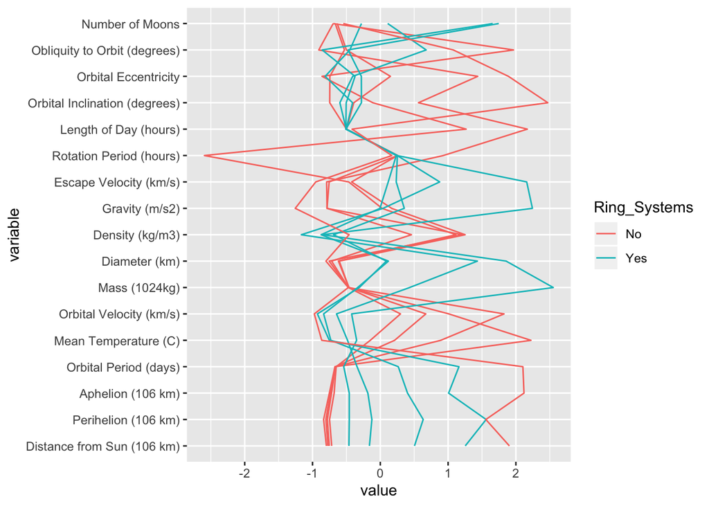

```
We draw the graph with high correlated columns being put together.

Orbital Period, Aphelion, Perihelion and Distance from Sun are highly correlated.

Planets with ring systems have larger diameter, mass, gravity, escape velocity and number of moons than planets without ring systems which makes sense.

Most planets without ring systems have larger obliquity to orbit, orbital eccentricity, orbital inclination, length of day and density than planets with ring systems.

There's an outlier in planets without ring systems on rotation period variable. There are also three outliers on planets with ring systems on escape velocity, gravity and mass variables.
```

```r
library(rvest)
library(purrr)
##read in data
planet_data = read_html('https://nssdc.gsfc.nasa.gov/planetary/factsheet/') %>% html_table()
planet_data = as.data.frame(planet_data)

##change col and row names and transpose the data
colnames(planet_data) = planet_data[1, ]
planet_data = planet_data[-1, ]
rownames(planet_data) = planet_data[, 1]
planet_data = planet_data[, -c(1, 5)]
planet_data = t(planet_data)
planet_data = as.data.frame(planet_data)

##remove comma and convert into numeric
planet_data[, 1:18] = map(planet_data[, 1:18], as.character)
planet_data[, 1:18] = map(planet_data[, 1:18], function(y) as.numeric(gsub(",", "", y)))
planet_data = as.data.frame(planet_data)

colnames(planet_data)[19] = 'Ring_Systems'
ggparcoord(planet_data, columns = c(8:11, 16, 12, 1:7, 13:15, 18), groupColumn = 19) +
  coord_flip()
```

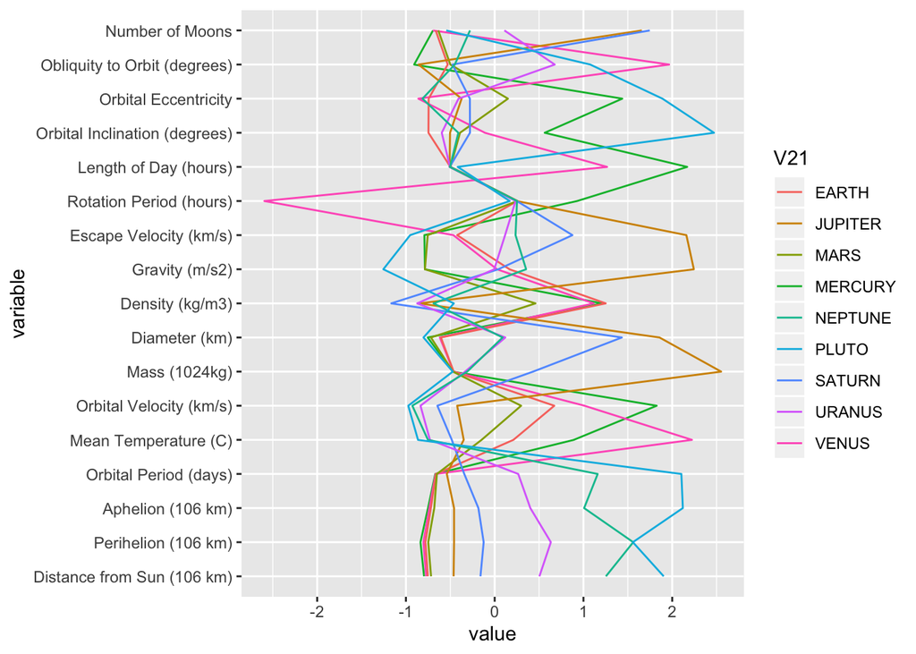

```
We draw the graph with high correlated columns being put together.

Orbital Period, Aphelion, Perihelion and Distance from Sun are highly correlated.

Venus has outliers on obliquity to orbit, length of day, rotation period and mean temperature.

Pluto has an outlier on orbital inclination.

Jupiter has outliers on escape velocity, gravity, diameter and mass because it's the largest planet in the solar system.
```

```r
ggparcoord(planet_data, columns = c(8:11, 16, 12, 1:7, 13:15, 18), groupColumn = 21) +
  coord_flip()
```

### 3. Heart Disease

Data: four data frames that begin with `heart_disease` in the **ucidata** package

Packages: You may use **vcd** or **ggmosaic**.

1. Create three mosaic plots, each involving two categorical variables from `heart_disease_cl` and interpret the plots. (You may reuse variables, for example X ~ Y and X ~ Z).

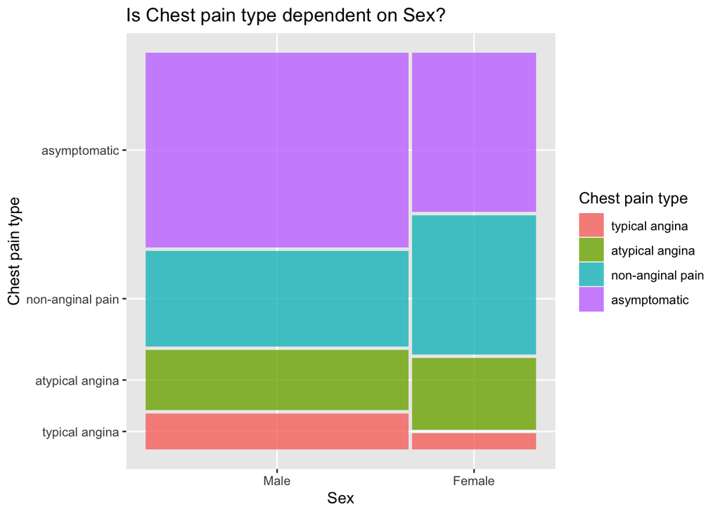

```
For this dataset, the chest pain type is dependent on the sex of the patient.
```

```r
heart_disease_cl %>%
  mutate(Sex = fct_relevel(sex, "Male"), `Chest pain type` = cp) %>%
  ggplot() +
  geom_mosaic(aes(x=product(`Chest pain type`, Sex), fill = `Chest pain type`)) +
  xlab("Sex") +
  ylab("Chest pain type") +
  ggtitle("Is Chest pain type dependent on Sex?")
```

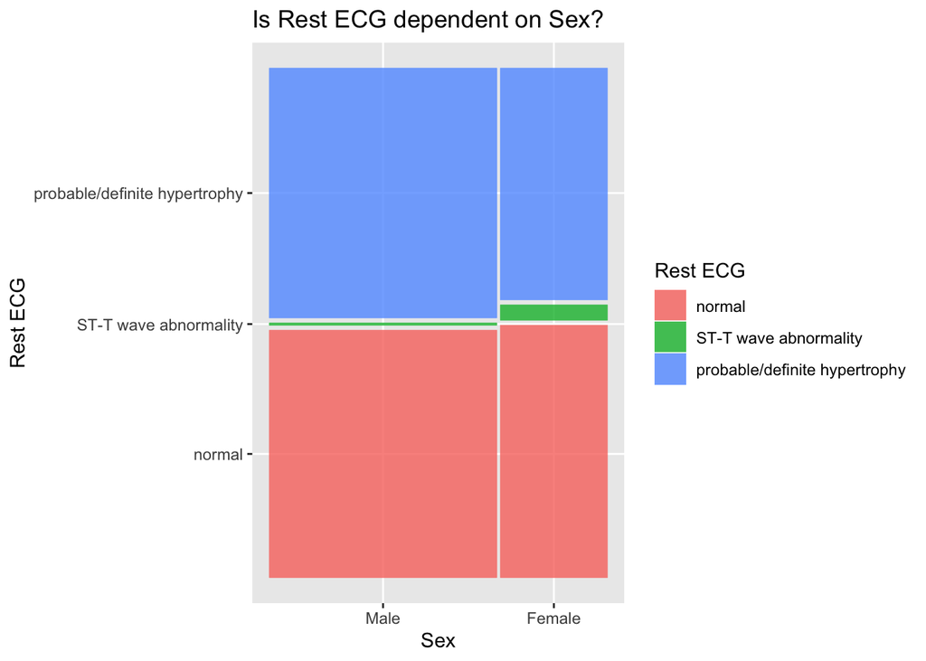

```
This mosaic plot shows that the "normal" Rest ECG is very close to being independent on the sex of the patient, which makes sense. Females experience slightly larger percentage of "ST-T wave abnormality".
```

```r
heart_disease_cl %>%
  mutate(Sex = fct_relevel(sex, "Male"), `Rest ECG` = restecg) %>%
  ggplot() +
  geom_mosaic(aes(x=product(`Rest ECG`, Sex), fill = `Rest ECG`)) +
  xlab("Sex") +
  ylab("Rest ECG") +
  ggtitle("Is Rest ECG dependent on Sex?")
```

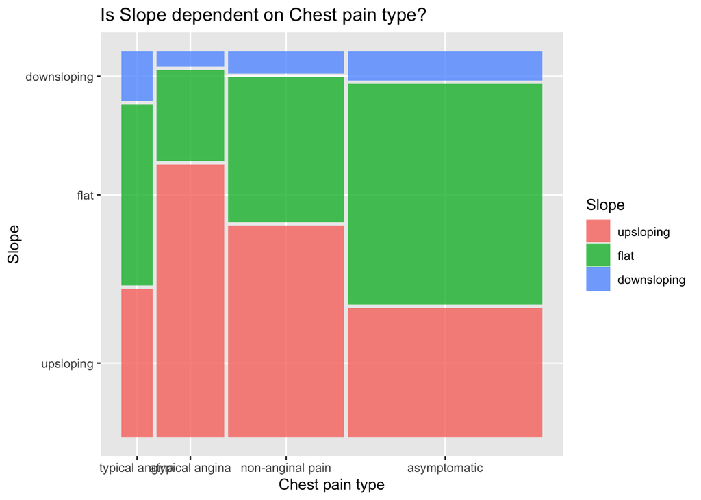

```
Yes, Slope is dependent of Chest pain type.
```

```r
heart_disease_cl %>%
  mutate(`Chest pain type` = cp, `Slope` = slope) %>%
  ggplot() +
  geom_mosaic(aes(x=product(slope, cp), fill = `Slope`)) +
  xlab("Chest pain type") +
  ylab("Slope") +
  ggtitle("Is Slope dependent on Chest pain type?")
```

2. Combine the four heart disease datasets and create a mosaic plot showing chest pain by sex and location. Describe any patterns.

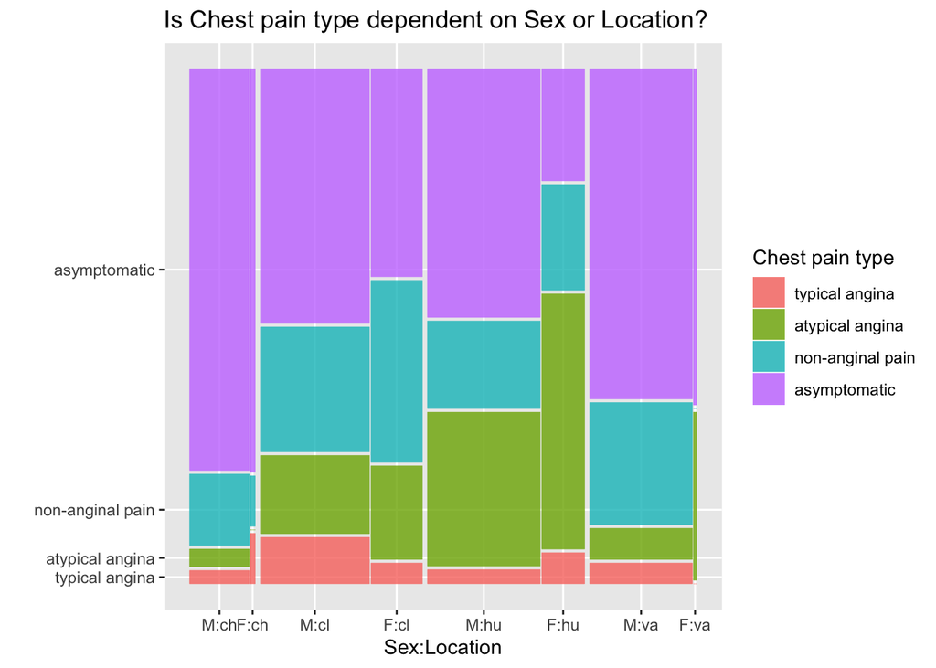

```
The most common chest pain type across sex and location is "asymptomatic", purple color is dominant on the plot, least common is "typical angina".
VA and Switzelend locations has a relatively small percentage of Females in the dataset. Because the sample size is not large enough for females in these two locations, we may not be able to draw impact conclusions based on thses samples. In all locations the number of Males was larger then Females.
Chest pain type is dependent on both Sex and Location.
```

```r
bind_rows(
  heart_disease_cl %>% dplyr::select(sex, cp) %>% mutate(location = "cl"),
  heart_disease_hu %>% dplyr::select(sex, cp) %>% mutate(location = "hu"),
  heart_disease_ch %>% dplyr::select(sex, cp) %>% mutate(location = "ch"),
  heart_disease_va %>% dplyr::select(sex, cp) %>% mutate(location = "va")
) %>%
  mutate(sex = fct_recode(fct_relevel(sex, "Male"), M = "Male", F = "Female")) %>%
  mutate(`Chest pain type` = cp) %>%
  ggplot() +
  geom_mosaic(aes(x=product(cp, sex, location), fill = `Chest pain type`), divider = ddecker()) +
  xlab("Sex:Location") +
  ylab("") +
  ggtitle("Is Chest pain type dependent on Sex or Location?")
```

### 4. District 3 Elementary Schools

Recently, there has been much debate about the lack of racial and economic diversity at Manhattan District 3 elementary schools, part of a larger and long-standing controversy about iniquities in the New York City public school system as a whole.

The *New York Times* article, “Rezoning Plan to Remake 3 Upper West Side Schools Will Proceed, City Says,” (https://www.nytimes.com/2016/11/10/nyregion/rezoning-plan-for-3-upper-west-side-schools-will-proceed-city-says.html) (2016-11-10) identifies the 11 elementary schools in Manhattan District 3.

For this question, we will analyze parent survey results for these schools.

Data: https://www.schools.nyc.gov/about-us/reports/school-quality/nyc-school-survey

1. Choose one of the likert style questions from the 2019 parent survey and use a diverging stacked bar chart to show results for the 11 schools identified in the article referenced above.

```r
get_school_survey_responses <- function (path, sheet, question, responses) {
  # Read only the colum names (2 rows)
  survey_columns <- read_excel(
    path = path,
    sheet = sheet,
    n_max = 1
  )
  # Fill down the column names to the values of first row
  survey_columns[1,1:2] <- survey_columns[0,1:2] %>% names()
  # Find the index of the question we want
  #print(colnames(survey_columns))
  question_start_column <- match(question, colnames(survey_columns))
  # col_indices contains a list of column indices to select for the specified question (including first 2 columns)
  col_indices = c(1:2, question_start_column:(question_start_column + length(responses) - 1))
  # col_names contains a list of corresponding column names
  col_names <- survey_columns[1, col_indices] %>% map(1) %>% as.character
  # Read only data (excluding column names)
  survey_data <- read_excel(
    path = path,
    sheet = sheet,
    skip = 2,
    col_names = FALSE,
    col_types = c("text", "text", rep("numeric", ncol(survey_columns)-2)),
    na = "N/A"
  )
  #print(col_indices)
  #print(col_names)
  survey_data %>%
    # Select only the columns we are interested in
    select_at(col_indices) %>%
    # Rename all columns
    set_names(col_names) %>%
    # Reorder columns in the order of responses
    dplyr::select(DBN, "School Name", responses)
}

#question = "2f. At this school my child is safe."
#question = "2g. The school is kept clean."
question = "5b. The education my child has received this year."
#question_responses = c("Strongly disagree", "Disagree", "I don't know", "Agree", "Strongly agree")
q2019 <- get_school_survey_responses(
  path = "PSet3-data/2019-public-data-file_parent.xlsx",
  sheet = " Parent %",
  question = question,
  responses = c("Very dissatisfied", "Dissatisfied", "I don't know", "Satisfied", "Very satisfied")
)
q2019
```

```
## # A tibble: 2,946 x 7
##    DBN   `School Name` `Very dissatisf… Dissatisfied `I don't know`
##    <chr> <chr>                    <dbl>        <dbl>          <dbl>
##  1 01M0… P.S. 015 ROB…                2            1              1
##  2 01M0… P.S. 019 ASH…                1            2              1
##  3 01M0… P.S. 020 ANN…                2            6              0
##  4 01M0… P.S. 034 FRA…                2            3              0
##  5 01M0… THE STAR ACA…                1            5              3
##  6 01M0… P.S. 064 ROB…                1            0              0
##  7 01M1… P.S. 110 FLO…                3            4              1
##  8 01M1… P.S. 134 HEN…                2            2              1
##  9 01M1… P.S. 140 NAT…                2            3              1
## 10 01M1… P.S. 142 AMA…                2            3              1
## # … with 2,936 more rows, and 2 more variables: Satisfied <dbl>, `Very
## #   satisfied` <dbl>
```

```r
school_numbers = c(165, 145, 163, 75, 84, 166, 9, 87, 452, 199, 191)
linkert_data <- q2019 %>%
  filter(DBN %in% paste("03M", str_pad(school_numbers, 3, pad = "0"), sep = "")) %>%
  mutate(School = paste("P.S.", substr(DBN, 4, 6)))

HH::likert(
  x = School ~ .,
  data = linkert_data,
  positive.order = TRUE,
  main = question,
  xlab = "percent", ylab = ""
)
```

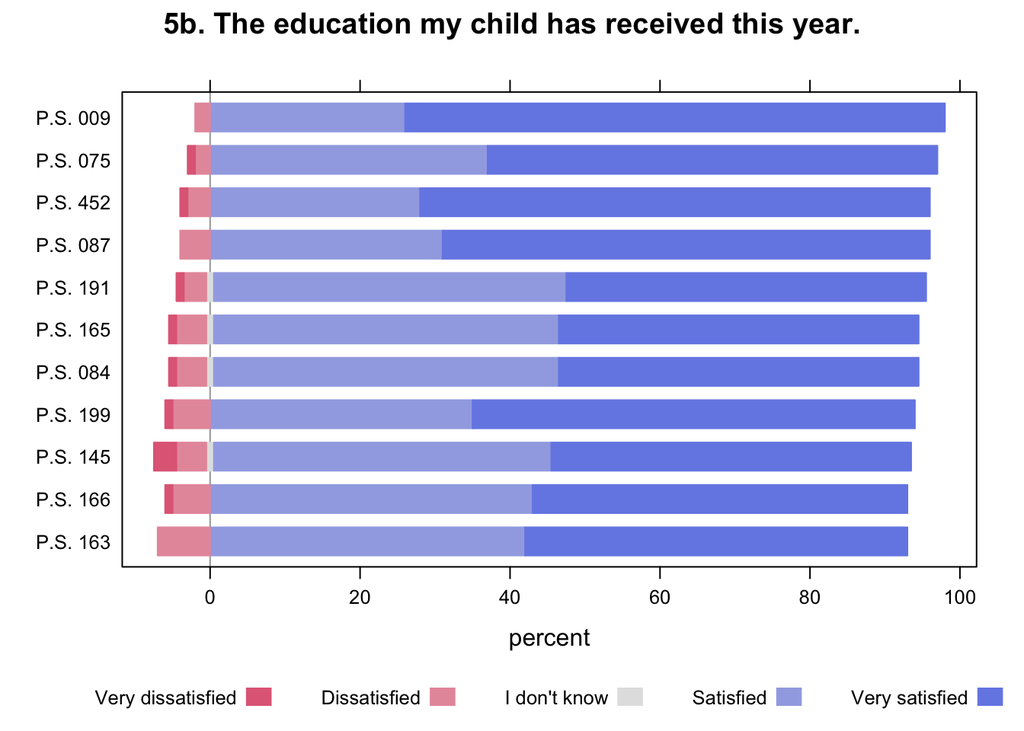

2. Choose a question that was asked in 2014 and 2019 and compare results for the three schools discussed most in the article: P.S. 199, P.S. 191, and P.S. 452. You may use two separate diverging stacked bar charts or combine all the information in one.

```r
q2019 <- get_school_survey_responses(
  path = "PSet3-data/2019-public-data-file_parent.xlsx",
  sheet = " Parent %",
  question = "2f. At this school my child is safe.",
  responses = c("Strongly disagree", "Disagree", "I don't know", "Agree", "Strongly agree")
) %>%
  filter(DBN %in% paste("03M", str_pad(c(199, 191, 452), 3, pad = "0"), sep = "")) %>%
  mutate(Year = "2019", School = paste("P.S.", substr(DBN, 4, 6))) %>%
  dplyr::select(-`I don't know`) # drop column that is not used in 2014 survey

q2014 <- get_school_survey_responses(
  path = "PSet3-data/2014_20School_20Survey.xlsx",
  sheet = "GenEd - Parent %",
  question = "2a. At my child's school my child is safe.",
  responses = c("Strongly disagree", "Disagree", "Agree", "Strongly agree")
) %>%
  filter(DBN %in% paste("03M", str_pad(c(199, 191, 452), 3, pad = "0"), sep = "")) %>%
  mutate(Year = "2014", School = paste("P.S.", substr(DBN, 4, 6)))

likert_data <- bind_rows(q2014, q2019)
```

```r
HH::likert(
  data = filter(likert_data, Year == '2014'),
  x = School ~ .,
  positive.order = FALSE,
  data.order = TRUE,
  main = "2014 survey question: At this school my child is safe",
  xlab = "percent", ylab = ""
)
```

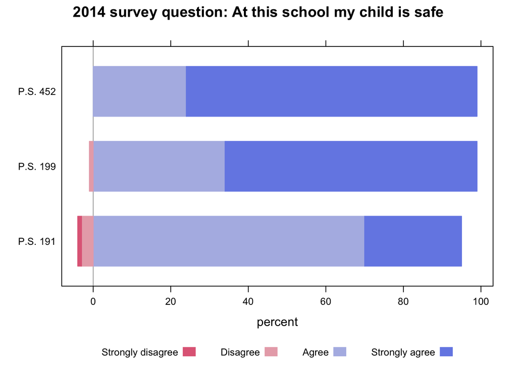

```r
HH::likert(
  data = filter(likert_data, Year == '2019'),
  x = School ~ .,
  positive.order = FALSE,
  data.order = TRUE,
  main = "2019 survey question: At this school my child is safe",
  xlab = "percent", ylab = ""
)
```

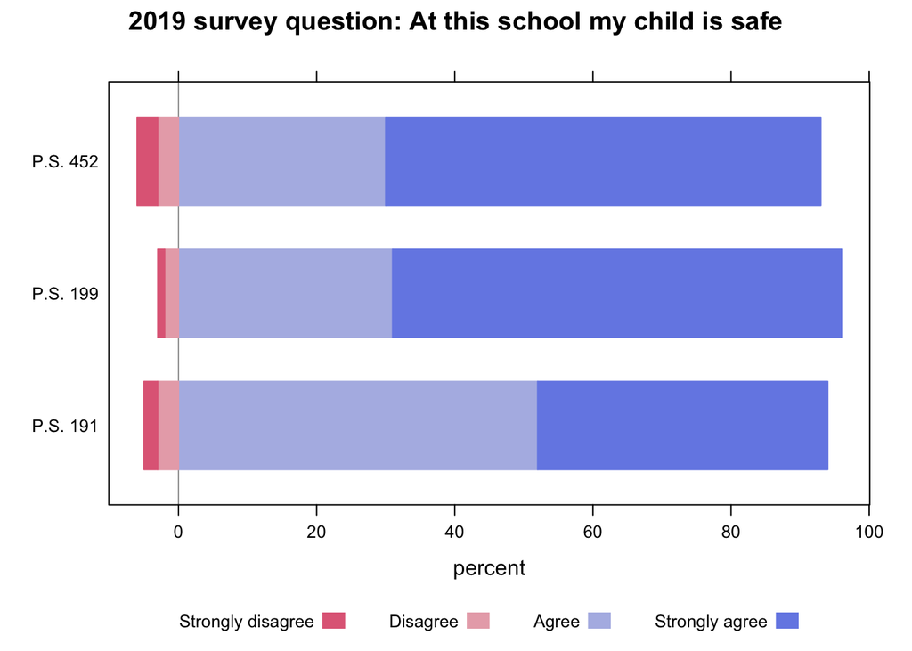

3. Interpret your findings of (b) in light of the reputations of the schools as presented in the article. Are they surprising or what you would have expected?

   In section (b) we looked at the survey results answering the question “At this school my child is safe”. It looks like for the schools discussed in the article (PS 452, PS 199 and PS 191) the feeling of parental security for their children has gone down, e.g. for PS 452 the number of parents disagreeing or strongly disagreeing increased from 0% to 6%. It is not very surprising, considering the point of the re-zoning was to inrease diversity of each school and mix kids from well-to-do families and kids from under-priveleged backgrounds.